# Group 7 BIA Capstone Project

Falmata Wako, Jay Agyemang, Justin Smith, Julianne Wertz

INFO 3500 - Senior Capstone/Project, Spring 2024

Prof. Andrew Urbaczewski

Copyright and distributed under an [MIT License](https://opensource.org/licenses/MIT)

## Acknowledgements

Much of this notebook's scraping section is from Prof. Andrew Urbaczewski who in turn begged, borrowed, and stole (with permission) from [Brian C. Keegan, Ph.D.](http://brianckeegan.com/)  
[Assistant Professor, Department of Information Science](https://www.colorado.edu/cmci/people/information-science/brian-c-keegan) at the University of Colorado.  
He in turn borrowed from resources he built with [Allison Morgan](https://allisonmorgan.github.io/) for the [2018 Summer Institute for Computational Social Science](https://github.com/allisonmorgan/sicss_boulder), which were derived from [other resources](https://github.com/simonmunzert/web-scraping-with-r-extended-edition) developed by [Simon Munzert](http://simonmunzert.github.io/) and [Chris Bail](http://www.chrisbail.net/).

The sentiment analysis material is adapted from Patrick Loeber's [awesome video](https://www.youtube.com/watch?v=8VZhog5C3bU).

Much of this is also adapted from the [PRAW documentation](https://praw.readthedocs.io/en/latest/).

Import Libraries

```python
# Lets us talk to other servers on the web
import requests
!pip install jupyter


# Handling dates and times
from datetime import datetime

# DataFrames!
import pandas as pd
import numpy as np

# Data visualization
%matplotlib inline
import matplotlib.pyplot as plt
import seaborn as sns

#Sentiment Analysis
import nltk
nltk.download('vader_lexicon')
from nltk.sentiment.vader import SentimentIntensityAnalyzer as SIA
```

```python
!pip install openpyxl
```

Scrapping Reddit

```python
!pip install praw
```

```python
import praw
```

```python
import os
from google.colab import drive
drive.mount('/content/drive')
```

```python
!cp '/content/drive/My Drive/Colab Notebooks/praw.ini' $HOME/.config
```

```python
#all my configuration information is in my praw.ini file
r = praw.Reddit('info3500', user_agent='research data script by /u/Falmata238')
```

```python
print(r.user.me())
```

## r/Schwab Data Scrapping

```python
# Initialize PRAW with your credentials
reddit = praw.Reddit(client_id='XSgoIvpkuSEVUUlRli7TWA',
                     client_secret='BGgAch-x9zpipnl4FrdPkRS9xiMs1g',
                     user_agent='Falmata238')

# List of submission URLs
submission_urls = [
    #Not happy with transition from TD to Schwab
    'https://www.reddit.com/r/Schwab/comments/13vumbz/not_happy_with_transition_from_td_to_schwab/',
    #I miss TD Ameritrade!!
    'https://www.reddit.com/r/Schwab/comments/1cg38sl/i_miss_td_ameritrade/',
    #TD Ameritrade customers want app back according to wall street journal..
    'https://www.reddit.com/r/Schwab/comments/16rzraa/td_ameritrade_customers_want_app_back_according/',
    #Anyone else from TD hate the Schwab app?
    'https://www.reddit.com/r/Schwab/comments/1cpxijs/anyone_else_from_td_hate_the_schwab_app/',
    #Td ameritrade
    'https://www.reddit.com/r/Schwab/comments/144dkcl/td_ameritrade/'
]

# Helper function to generate hierarchical comment IDs
def generate_comment_hierarchy(submission):
    comment_id_map = {submission.id: '1'}
    comment_hierarchy = []

    def add_comments(comments, parent_id):
        current_level = len(comment_hierarchy)
        for i, comment in enumerate(comments, 1):
            if isinstance(comment, praw.models.MoreComments):
                continue
            comment_id = f"{comment_id_map[parent_id]}_{i}"
            comment_id_map[comment.id] = comment_id
            comment_hierarchy.append({
                'url': submission.url,
                'author': comment.author.name if comment.author else 'N/A',
                'date': datetime.fromtimestamp(comment.created_utc).strftime('%Y-%m-%d %H:%M:%S'),
                'score': comment.score,
                'upvotes': comment.ups,
                'downvotes': comment.downs,
                'golds': comment.gilded,
                'comment': comment.body,
                'comment_id': comment_id,
                'post_title': submission.title,
                'post_text': submission.selftext,
                'subreddit': submission.subreddit.display_name
            })
            add_comments(comment.replies, comment.id)

    add_comments(submission.comments, submission.id)
    return comment_hierarchy

# Prepare a list to hold all comment details from all posts
all_comments = []

# Loop through each submission URL
for submission_url in submission_urls:
    # Extract the submission ID from the URL
    submission_id = submission_url.split('/')[-3]

    # Fetch the submission
    submission = reddit.submission(id=submission_id)

    # Fetch the submission details
    submission.comments.replace_more(limit=None)  # Handle cases with more than 1 level of comments

    # Generate hierarchical comments
    all_comments.extend(generate_comment_hierarchy(submission))

# Create a DataFrame from the list of all comments
schwabdf = pd.DataFrame(all_comments)
```

```python
# Display the DataFrame
schwabdf
```

|  | url | author | date | score | upvotes | downvotes | golds | comment | comment_id | post_title | post_text | subreddit |
| --- | --- | --- | --- | --- | --- | --- | --- | --- | --- | --- | --- | --- |
| 0 | https://www.reddit.com/r/Schwab/comments/13vum... | iwantac8 | 2023-05-30 18:56:55 | 32 | 32 | 0 | 0 | Providing feedback is the key here... The more... | 1_1 | Not happy with transition from TD to Schwab | The old TD Ameritrade website (and mobile app)... | Schwab |
| 1 | https://www.reddit.com/r/Schwab/comments/13vum... | N/A | 2023-05-31 02:37:21 | 17 | 17 | 0 | 0 | And to add, providing feedback POLITELY. Reps ... | 1_1_1 | Not happy with transition from TD to Schwab | The old TD Ameritrade website (and mobile app)... | Schwab |
| 2 | https://www.reddit.com/r/Schwab/comments/13vum... | farmecologist | 2023-06-01 19:43:02 | 5 | 5 | 0 | 0 | I get it...but why the heck didn't Schwab at l... | 1_1_1_1 | Not happy with transition from TD to Schwab | The old TD Ameritrade website (and mobile app)... | Schwab |
| 3 | https://www.reddit.com/r/Schwab/comments/13vum... | N/A | 2023-06-01 21:00:32 | 4 | 4 | 0 | 0 | I don’t know. I get it. It’s frustrating. Howe... | 1_1_1_1_1 | Not happy with transition from TD to Schwab | The old TD Ameritrade website (and mobile app)... | Schwab |
| 4 | https://www.reddit.com/r/Schwab/comments/13vum... | farmecologist | 2023-06-01 21:05:37 | 3 | 3 | 0 | 0 | Absolutely...first line customer service alway... | 1_1_1_1_1_1 | Not happy with transition from TD to Schwab | The old TD Ameritrade website (and mobile app)... | Schwab |
| ... | ... | ... | ... | ... | ... | ... | ... | ... | ... | ... | ... | ... |
| 698 | https://www.reddit.com/r/Schwab/comments/144dk... | Turbulent_Cricket497 | 2023-06-09 13:54:57 | 3 | 3 | 0 | 0 | Do you think Schwab will view this sub and ack... | 1_13_2_1 | Td ameritrade | This app is complete garbage compared to td am... | Schwab |
| 699 | https://www.reddit.com/r/Schwab/comments/144dk... | monogreenforthewin | 2023-06-09 14:08:08 | 3 | 3 | 0 | 0 | i doubt it. i just got the phone with customer... | 1_13_2_1_1 | Td ameritrade | This app is complete garbage compared to td am... | Schwab |
| 700 | https://www.reddit.com/r/Schwab/comments/144dk... | Raztan | 2023-06-09 15:06:54 | 1 | 1 | 0 | 0 | I find it more complicated to navigate, but a ... | 1_13_3 | Td ameritrade | This app is complete garbage compared to td am... | Schwab |
| 701 | https://www.reddit.com/r/Schwab/comments/144dk... | Raztan | 2023-06-09 15:04:28 | 1 | 1 | 0 | 0 | agree their app is garbage, their website is o... | 1_14 | Td ameritrade | This app is complete garbage compared to td am... | Schwab |
| 702 | https://www.reddit.com/r/Schwab/comments/144dk... | JCPWARRIORS | 2024-01-05 19:56:28 | 1 | 1 | 0 | 0 | On the other hand as a Schwab client....I DO N... | 1_15 | Td ameritrade | This app is complete garbage compared to td am... | Schwab |

703 rows × 12 columns

Save data to excel - saving to csv creates some data issues

```python
# Save the DataFrame to an Excel file
schwabdf.to_excel('Schwab_data.xlsx', index=False, engine='openpyxl')
```

## r/TD Ameritrade Data Scrapping

```python
# Initialize PRAW with your credentials
reddit = praw.Reddit(client_id='XSgoIvpkuSEVUUlRli7TWA',
                     client_secret='BGgAch-x9zpipnl4FrdPkRS9xiMs1g',
                     user_agent='Falmata238')

# List of submission URLs
submission_urls = [
    #Charles Schwab sucks!
    'https://www.reddit.com/r/tdameritrade/comments/18llbx4/charles_schwab_sucks/',
    #Schwab is a fucking joke
    'https://www.reddit.com/r/tdameritrade/comments/1axjnpv/schwab_is_a_fucking_joke/',
    #Schwab sucks so hard
    'https://www.reddit.com/r/tdameritrade/comments/1cr42jt/schwab_sucks_so_hard/',
    #Charles Schwab
    'https://www.reddit.com/r/tdameritrade/comments/18745xa/charles_schwab/',
    #Is the migration to Schwab that bad?
    'https://www.reddit.com/r/tdameritrade/comments/1axx4uc/is_the_migration_to_schwab_that_bad/'
]

# Helper function to generate hierarchical comment IDs
def generate_comment_hierarchy(submission):
    comment_id_map = {submission.id: '1'}
    comment_hierarchy = []

    def add_comments(comments, parent_id):
        current_level = len(comment_hierarchy)
        for i, comment in enumerate(comments, 1):
            if isinstance(comment, praw.models.MoreComments):
                continue
            comment_id = f"{comment_id_map[parent_id]}_{i}"
            comment_id_map[comment.id] = comment_id
            comment_hierarchy.append({
                'url': submission.url,
                'author': comment.author.name if comment.author else 'N/A',
                'date': datetime.fromtimestamp(comment.created_utc).strftime('%Y-%m-%d %H:%M:%S'),
                'score': comment.score,
                'upvotes': comment.ups,
                'downvotes': comment.downs,
                'golds': comment.gilded,
                'comment': comment.body,
                'comment_id': comment_id,
                'post_title': submission.title,
                'post_text': submission.selftext,
                'subreddit': submission.subreddit.display_name
            })
            add_comments(comment.replies, comment.id)

    add_comments(submission.comments, submission.id)
    return comment_hierarchy

# Prepare a list to hold all comment details from all posts
all_comments = []

# Loop through each submission URL
for submission_url in submission_urls:
    # Extract the submission ID from the URL
    submission_id = submission_url.split('/')[-3]

    # Fetch the submission
    submission = reddit.submission(id=submission_id)

    # Fetch the submission details
    submission.comments.replace_more(limit=None)  # Handle cases with more than 1 level of comments

    # Generate hierarchical comments
    all_comments.extend(generate_comment_hierarchy(submission))

# Create a DataFrame from the list of all comments
TDdf = pd.DataFrame(all_comments)
```

```python
# Display the DataFrame
TDdf
```

|  | url | author | date | score | upvotes | downvotes | golds | comment | comment_id | post_title | post_text | subreddit |
| --- | --- | --- | --- | --- | --- | --- | --- | --- | --- | --- | --- | --- |
| 0 | https://www.reddit.com/r/tdameritrade/comments... | DeepRiverSSV | 2023-12-18 23:09:32 | 12 | 12 | 0 | 0 | back in 2018, moved my accounts to TDAmeritrad... | 1_1 | Charles Schwab sucks! | I am moving my six figure account to Fidelity.... | tdameritrade |
| 1 | https://www.reddit.com/r/tdameritrade/comments... | HandIcy161 | 2023-12-19 03:13:02 | 1 | 1 | 0 | 0 | Definitely worth the hassle, also Fidelity loo... | 1_1_1 | Charles Schwab sucks! | I am moving my six figure account to Fidelity.... | tdameritrade |
| 2 | https://www.reddit.com/r/tdameritrade/comments... | DeepRiverSSV | 2023-12-19 05:27:36 | 3 | 3 | 0 | 0 | Thanks! Still have a 529 plan there that I di... | 1_1_1_1 | Charles Schwab sucks! | I am moving my six figure account to Fidelity.... | tdameritrade |
| 3 | https://www.reddit.com/r/tdameritrade/comments... | N/A | 2024-01-16 15:37:02 | 1 | 1 | 0 | 0 | Fidelity is slow with putting in orders. Not g... | 1_1_2 | Charles Schwab sucks! | I am moving my six figure account to Fidelity.... | tdameritrade |
| 4 | https://www.reddit.com/r/tdameritrade/comments... | Chuysfan | 2023-12-21 18:06:37 | 5 | 5 | 0 | 0 | Schwab sucks so bad, I've been downloading var... | 1_2 | Charles Schwab sucks! | I am moving my six figure account to Fidelity.... | tdameritrade |
| ... | ... | ... | ... | ... | ... | ... | ... | ... | ... | ... | ... | ... |
| 685 | https://www.reddit.com/r/tdameritrade/comments... | Ill-Independence-658 | 2024-02-24 15:10:26 | 1 | 1 | 0 | 0 | It’s fine. They even give you level II order f... | 1_60 | Is the migration to Schwab that bad? | I see tons of new posts either complaining or ... | tdameritrade |
| 686 | https://www.reddit.com/r/tdameritrade/comments... | steevithak | 2024-02-24 16:01:37 | 1 | 1 | 0 | 0 | It's not bad at this point. When the migration... | 1_61 | Is the migration to Schwab that bad? | I see tons of new posts either complaining or ... | tdameritrade |
| 687 | https://www.reddit.com/r/tdameritrade/comments... | Pocket_Lint_Ball | 2024-02-26 13:47:43 | 1 | 1 | 0 | 0 | DRS everything, trust none of them. | 1_62 | Is the migration to Schwab that bad? | I see tons of new posts either complaining or ... | tdameritrade |
| 688 | https://www.reddit.com/r/tdameritrade/comments... | Eateator | 2024-02-28 00:49:25 | 1 | 1 | 0 | 0 | Internet is mainly a complaint storage system. | 1_63 | Is the migration to Schwab that bad? | I see tons of new posts either complaining or ... | tdameritrade |
| 689 | https://www.reddit.com/r/tdameritrade/comments... | onphyre | 2024-02-28 01:28:39 | 1 | 1 | 0 | 0 | No issue with the conversion, but I liked the ... | 1_64 | Is the migration to Schwab that bad? | I see tons of new posts either complaining or ... | tdameritrade |

690 rows × 12 columns

Save data to excel - saving to csv creates data issues

```python
# Save the DataFrame to an Excel file
TDdf.to_excel('TD_data.xlsx', index=False, engine='openpyxl')
```

## r/Investing Data Scrapping

```python
# Initialize PRAW with your credentials
reddit = praw.Reddit(client_id='XSgoIvpkuSEVUUlRli7TWA',
                     client_secret='BGgAch-x9zpipnl4FrdPkRS9xiMs1g',
                     user_agent='Falmata238')

# List of submission URLs
submission_urls = [
    #Charles Schwab App is horrible
    'https://www.reddit.com/r/investing/comments/1cev38m/charles_schwab_app_is_horrible/',
    #The Schwab app is garbage and I miss TDA
    'https://www.reddit.com/r/investing/comments/13wj08y/the_schwab_app_is_garbage_and_i_miss_tda/',
    #People who were transitioned from TD Ameritrade to Schwab, do any of you actually like Schwab?
    'https://www.reddit.com/r/investing/comments/142rvp5/people_who_were_transitioned_from_td_ameritrade/',
    #Schwab ? Making the change 😬 ?
    'https://www.reddit.com/r/investing/comments/1b1lb90/schwab_making_the_change/',
    #I can't continue with the charles schwab app.
    'https://www.reddit.com/r/investing/comments/1bp383z/i_cant_continue_with_the_charles_schwab_app/'
]

# Helper function to generate hierarchical comment IDs
def generate_comment_hierarchy(submission):
    comment_id_map = {submission.id: '1'}
    comment_hierarchy = []

    def add_comments(comments, parent_id):
        current_level = len(comment_hierarchy)
        for i, comment in enumerate(comments, 1):
            if isinstance(comment, praw.models.MoreComments):
                continue
            comment_id = f"{comment_id_map[parent_id]}_{i}"
            comment_id_map[comment.id] = comment_id
            comment_hierarchy.append({
                'url': submission.url,
                'author': comment.author.name if comment.author else 'N/A',
                'date': datetime.fromtimestamp(comment.created_utc).strftime('%Y-%m-%d %H:%M:%S'),
                'score': comment.score,
                'upvotes': comment.ups,
                'downvotes': comment.downs,
                'golds': comment.gilded,
                'comment': comment.body,
                'comment_id': comment_id,
                'post_title': submission.title,
                'post_text': submission.selftext,
                'subreddit': submission.subreddit.display_name
            })
            add_comments(comment.replies, comment.id)

    add_comments(submission.comments, submission.id)
    return comment_hierarchy

# Prepare a list to hold all comment details from all posts
all_comments = []

# Loop through each submission URL
for submission_url in submission_urls:
    # Extract the submission ID from the URL
    submission_id = submission_url.split('/')[-3]

    # Fetch the submission
    submission = reddit.submission(id=submission_id)

    # Fetch the submission details
    submission.comments.replace_more(limit=None)  # Handle cases with more than 1 level of comments

    # Generate hierarchical comments
    all_comments.extend(generate_comment_hierarchy(submission))

# Create a DataFrame from the list of all comments
Investingdf = pd.DataFrame(all_comments)
```

```python
# Display the DataFrame
Investingdf
```

|  | url | author | date | score | upvotes | downvotes | golds | comment | comment_id | post_title | post_text | subreddit |
| --- | --- | --- | --- | --- | --- | --- | --- | --- | --- | --- | --- | --- |
| 0 | https://www.reddit.com/r/investing/comments/1c... | TheGodDavidLoPan | 2024-04-28 03:22:50 | 118 | 118 | 0 | 0 | Nothing will beat the old TD Ameritrade, but C... | 1_1 | Charles Schwab App is horrible | Almost a year after acquiring TD , I still don... | investing |
| 1 | https://www.reddit.com/r/investing/comments/1c... | smblt | 2024-04-29 18:15:11 | 2 | 2 | 0 | 0 | I'm using ToS right now but I still liked the ... | 1_1_1 | Charles Schwab App is horrible | Almost a year after acquiring TD , I still don... | investing |
| 2 | https://www.reddit.com/r/investing/comments/1c... | TheGodDavidLoPan | 2024-04-29 18:52:54 | 1 | 1 | 0 | 0 | CS should've just stolen TD's mobile app UI. T... | 1_1_1_1 | Charles Schwab App is horrible | Almost a year after acquiring TD , I still don... | investing |
| 3 | https://www.reddit.com/r/investing/comments/1c... | Honest-Caramel-4879 | 2024-05-10 02:30:23 | 1 | 1 | 0 | 0 | I wish CS will read all comments, otherwise it... | 1_1_1_1_1 | Charles Schwab App is horrible | Almost a year after acquiring TD , I still don... | investing |
| 4 | https://www.reddit.com/r/investing/comments/1c... | Honest-Caramel-4879 | 2024-05-10 02:21:43 | 1 | 1 | 0 | 0 | I left CS with a fraction on it, moved to TD A... | 1_1_1_2 | Charles Schwab App is horrible | Almost a year after acquiring TD , I still don... | investing |
| ... | ... | ... | ... | ... | ... | ... | ... | ... | ... | ... | ... | ... |
| 838 | https://www.reddit.com/r/investing/comments/1b... | greytoc | 2024-03-27 16:02:15 | 1 | 1 | 0 | 0 | You doubt that they will complete the transiti... | 1_13_1_2_2 | I can't continue with the charles schwab app. | The user interface of the schwab app compared ... | investing |
| 839 | https://www.reddit.com/r/investing/comments/1b... | theyipper | 2024-03-27 18:02:57 | 1 | 1 | 0 | 0 | My accounts finished xfer about 2 months ago. ... | 1_13_1_3 | I can't continue with the charles schwab app. | The user interface of the schwab app compared ... | investing |
| 840 | https://www.reddit.com/r/investing/comments/1b... | greytoc | 2024-03-27 18:21:20 | 1 | 1 | 0 | 0 | lol - that's a long time ago. And you are much... | 1_13_1_3_1 | I can't continue with the charles schwab app. | The user interface of the schwab app compared ... | investing |
| 841 | https://www.reddit.com/r/investing/comments/1b... | theyipper | 2024-03-27 18:22:52 | 1 | 1 | 0 | 0 | Haha, Schwab really wants your business! | 1_13_1_3_1_1 | I can't continue with the charles schwab app. | The user interface of the schwab app compared ... | investing |
| 842 | https://www.reddit.com/r/investing/comments/1b... | InformalBasil | 2024-03-27 22:14:40 | 0 | 0 | 0 | 0 | I feel that same, I'm actually tempted to swit... | 1_14 | I can't continue with the charles schwab app. | The user interface of the schwab app compared ... | investing |

843 rows × 12 columns

Save data to excel - saving to csv creates data issues

```python
# Save the DataFrame to an Excel file
Investingdf.to_excel('Investing_data.xlsx', index=False, engine='openpyxl')
```

## Combined Data

```python
# Combine the dataframes into one
combined_df = pd.concat([schwabdf, TDdf, Investingdf], ignore_index=True)

# Display the combined dataframe
combined_df
```

|  | url | author | date | score | upvotes | downvotes | golds | comment | comment_id | post_title | post_text | subreddit |
| --- | --- | --- | --- | --- | --- | --- | --- | --- | --- | --- | --- | --- |
| 0 | https://www.reddit.com/r/Schwab/comments/13vum... | iwantac8 | 2023-05-30 18:56:55 | 32 | 32 | 0 | 0 | Providing feedback is the key here... The more... | 1_1 | Not happy with transition from TD to Schwab | The old TD Ameritrade website (and mobile app)... | Schwab |
| 1 | https://www.reddit.com/r/Schwab/comments/13vum... | N/A | 2023-05-31 02:37:21 | 17 | 17 | 0 | 0 | And to add, providing feedback POLITELY. Reps ... | 1_1_1 | Not happy with transition from TD to Schwab | The old TD Ameritrade website (and mobile app)... | Schwab |
| 2 | https://www.reddit.com/r/Schwab/comments/13vum... | farmecologist | 2023-06-01 19:43:02 | 5 | 5 | 0 | 0 | I get it...but why the heck didn't Schwab at l... | 1_1_1_1 | Not happy with transition from TD to Schwab | The old TD Ameritrade website (and mobile app)... | Schwab |
| 3 | https://www.reddit.com/r/Schwab/comments/13vum... | N/A | 2023-06-01 21:00:32 | 4 | 4 | 0 | 0 | I don’t know. I get it. It’s frustrating. Howe... | 1_1_1_1_1 | Not happy with transition from TD to Schwab | The old TD Ameritrade website (and mobile app)... | Schwab |
| 4 | https://www.reddit.com/r/Schwab/comments/13vum... | farmecologist | 2023-06-01 21:05:37 | 3 | 3 | 0 | 0 | Absolutely...first line customer service alway... | 1_1_1_1_1_1 | Not happy with transition from TD to Schwab | The old TD Ameritrade website (and mobile app)... | Schwab |
| ... | ... | ... | ... | ... | ... | ... | ... | ... | ... | ... | ... | ... |
| 2231 | https://www.reddit.com/r/investing/comments/1b... | greytoc | 2024-03-27 16:02:15 | 1 | 1 | 0 | 0 | You doubt that they will complete the transiti... | 1_13_1_2_2 | I can't continue with the charles schwab app. | The user interface of the schwab app compared ... | investing |
| 2232 | https://www.reddit.com/r/investing/comments/1b... | theyipper | 2024-03-27 18:02:57 | 1 | 1 | 0 | 0 | My accounts finished xfer about 2 months ago. ... | 1_13_1_3 | I can't continue with the charles schwab app. | The user interface of the schwab app compared ... | investing |
| 2233 | https://www.reddit.com/r/investing/comments/1b... | greytoc | 2024-03-27 18:21:20 | 1 | 1 | 0 | 0 | lol - that's a long time ago. And you are much... | 1_13_1_3_1 | I can't continue with the charles schwab app. | The user interface of the schwab app compared ... | investing |
| 2234 | https://www.reddit.com/r/investing/comments/1b... | theyipper | 2024-03-27 18:22:52 | 1 | 1 | 0 | 0 | Haha, Schwab really wants your business! | 1_13_1_3_1_1 | I can't continue with the charles schwab app. | The user interface of the schwab app compared ... | investing |
| 2235 | https://www.reddit.com/r/investing/comments/1b... | InformalBasil | 2024-03-27 22:14:40 | 0 | 0 | 0 | 0 | I feel that same, I'm actually tempted to swit... | 1_14 | I can't continue with the charles schwab app. | The user interface of the schwab app compared ... | investing |

2236 rows × 12 columns

Saving combined df into excel

```python
# Save the DataFrame to an Excel file
combined_df.to_excel('Combined_data.xlsx', index=False, engine='openpyxl')
```

### Word Cloud on the Comments of the Combined Data

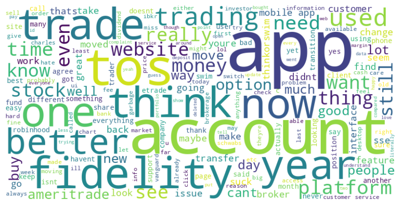

```python
from wordcloud import WordCloud, STOPWORDS
import matplotlib.pyplot as plt
import re
import string

# Sample data for combined_df
# combined_df = pd.DataFrame({'comment': ['Example comment about Schwab and TD Ameritrade.', 'Another comment with emojis 😊 and special characters!']})

# Function to clean text
def clean_text(text):
    # Convert to lowercase
    text = text.lower()
    # Remove URLs
    text = re.sub(r'http\S+|www\S+|https\S+', '', text, flags=re.MULTILINE)
    # Remove special characters, emojis, and punctuations
    text = re.sub(r'[^a-zA-Z\s]', '', text)
    # Remove newlines and extra spaces
    text = re.sub(r'\s+', ' ', text).strip()
    return text

# List of additional stopwords to remove
additional_stopwords = set([
    'schwab', 'td', 'td ameritrade', 'investing', 'tda', 'charles schwab', 'im', 'dont', 'will', 'ive','use'
])

# Clean the comments and remove stopwords
combined_df['cleaned_comment'] = combined_df['comment'].apply(clean_text)

# Combine all comments into a single string
all_comments = ' '.join(combined_df['cleaned_comment'].tolist())

# Add additional stopwords to the default stopwords set
stopwords = STOPWORDS.union(additional_stopwords)

# Generate the word cloud
wordcloud = WordCloud(
    stopwords=stopwords,
    background_color='white',
    width=800,
    height=400
).generate(all_comments)

# Plot the word cloud
plt.figure(figsize=(10, 5))
plt.imshow(wordcloud, interpolation='bilinear')
plt.axis('off')
plt.show()
```

### r/Schwab Word Cloud

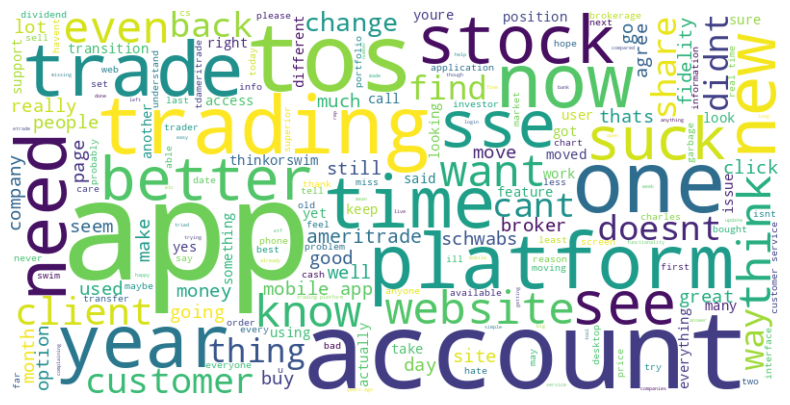

```python
# Function to clean text
def clean_text(text):
    # Convert to lowercase
    text = text.lower()
    # Remove URLs
    text = re.sub(r'http\S+|www\S+|https\S+', '', text, flags=re.MULTILINE)
    # Remove special characters, emojis, and punctuations
    text = re.sub(r'[^a-zA-Z\s]', '', text)
    # Remove newlines and extra spaces
    text = re.sub(r'\s+', ' ', text).strip()
    return text

# List of additional stopwords to remove
additional_stopwords = set([
    'schwab', 'td', 'td ameritrade', 'investing', 'tda', 'charles schwab', 'im', 'dont', 'will', 'ive','use'
])

# Clean the comments and remove stopwords
schwabdf['cleaned_comment'] = schwabdf['comment'].apply(clean_text)

# Combine all comments into a single string
all_comments_schwab = ' '.join(schwabdf['cleaned_comment'].tolist())

# Add additional stopwords to the default stopwords set
stopwords = STOPWORDS.union(additional_stopwords)

# Generate the word cloud
wordcloud = WordCloud(
    stopwords=stopwords,
    background_color='white',
    width=800,
    height=400
).generate(all_comments_schwab)

# Plot the word cloud
plt.figure(figsize=(10, 5))
plt.imshow(wordcloud, interpolation='bilinear')
plt.axis('off')
plt.show()
```

### r/TDAmeritrade Word Cloud

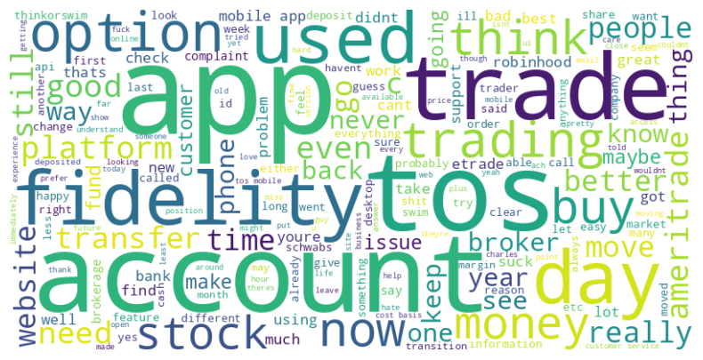

```python
# Function to clean text
def clean_text(text):
    # Convert to lowercase
    text = text.lower()
    # Remove URLs
    text = re.sub(r'http\S+|www\S+|https\S+', '', text, flags=re.MULTILINE)
    # Remove special characters, emojis, and punctuations
    text = re.sub(r'[^a-zA-Z\s]', '', text)
    # Remove newlines and extra spaces
    text = re.sub(r'\s+', ' ', text).strip()
    return text

# List of additional stopwords to remove
additional_stopwords = set([
    'schwab', 'td', 'td ameritrade', 'investing', 'tda', 'charles schwab', 'im', 'dont', 'will', 'ive','use'
])

# Clean the comments and remove stopwords
TDdf['cleaned_comment'] = TDdf['comment'].apply(clean_text)

# Combine all comments into a single string
all_comments_TD = ' '.join(TDdf['cleaned_comment'].tolist())

# Add additional stopwords to the default stopwords set
stopwords = STOPWORDS.union(additional_stopwords)

# Generate the word cloud
wordcloud = WordCloud(
    stopwords=stopwords,
    background_color='white',
    width=800,
    height=400
).generate(all_comments_TD)

# Plot the word cloud
plt.figure(figsize=(10, 5))
plt.imshow(wordcloud, interpolation='bilinear')
plt.axis('off')
plt.show()
```

### r/Investing Word Cloud

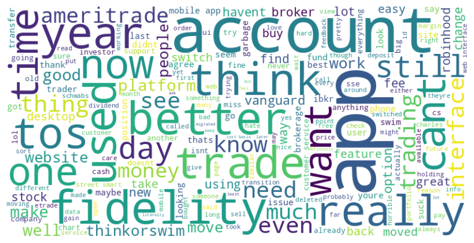

```python
# Function to clean text
def clean_text(text):
    # Convert to lowercase
    text = text.lower()
    # Remove URLs
    text = re.sub(r'http\S+|www\S+|https\S+', '', text, flags=re.MULTILINE)
    # Remove special characters, emojis, and punctuations
    text = re.sub(r'[^a-zA-Z\s]', '', text)
    # Remove newlines and extra spaces
    text = re.sub(r'\s+', ' ', text).strip()
    return text

# List of additional stopwords to remove
additional_stopwords = set([
    'schwab', 'td', 'td ameritrade', 'investing', 'tda', 'charles schwab', 'im', 'dont', 'will', 'ive','use'
])

# Clean the comments and remove stopwords
Investingdf['cleaned_comment'] = Investingdf['comment'].apply(clean_text)

# Combine all comments into a single string
all_comments_investing = ' '.join(Investingdf['cleaned_comment'].tolist())

# Add additional stopwords to the default stopwords set
stopwords = STOPWORDS.union(additional_stopwords)

# Generate the word cloud
wordcloud = WordCloud(
    stopwords=stopwords,
    background_color='white',
    width=800,
    height=400
).generate(all_comments_investing)

# Plot the word cloud
plt.figure(figsize=(10, 5))
plt.imshow(wordcloud, interpolation='bilinear')
plt.axis('off')
plt.show()
```

### Combined Data Word Frequency on the Comments

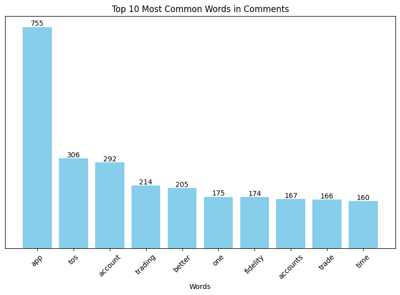

```python
import pandas as pd
from collections import Counter
import re
import matplotlib.pyplot as plt
from wordcloud import STOPWORDS

# Sample combined_df data
# combined_df = pd.DataFrame({'comment': ['Example comment about Schwab and TD Ameritrade.', 'Another comment with emojis 😊 and special characters!']})

# Function to clean text
def clean_text(text):
    # Convert to lowercase
    text = text.lower()
    # Remove URLs
    text = re.sub(r'http\S+|www\S+|https\S+', '', text, flags=re.MULTILINE)
    # Remove special characters, emojis, and punctuations
    text = re.sub(r'[^a-zA-Z\s]', '', text)
    # Remove newlines and extra spaces
    text = re.sub(r'\s+', ' ', text).strip()
    return text

# List of additional stopwords to remove
additional_stopwords = set([
    'schwab', 'td', 'td ameritrade', 'investing', 'tda', 'charles schwab', 'im', 'dont', 'will', 'ive','use', 'now', 'think', 'used'
])

# Clean the comments and remove stopwords
combined_df['cleaned_comment'] = combined_df['comment'].apply(clean_text)

# Combine all comments into a single string
all_comments = ' '.join(combined_df['cleaned_comment'].tolist())

# Split the combined string into words
words = all_comments.split()

# Remove stopwords from the words list
filtered_words = [word for word in words if word not in additional_stopwords and word not in STOPWORDS]

# Get the frequency of each word
word_freq = Counter(filtered_words)

# Convert the frequency data to a DataFrame for better visualization
freq_df = pd.DataFrame(word_freq.items(), columns=['Word', 'Frequency']).sort_values(by='Frequency', ascending=False)

# Get the top 10 most common words
top_10_words = freq_df.head(10)

# Plot the top 10 most common words
plt.figure(figsize=(10, 6))
bars = plt.bar(top_10_words['Word'], top_10_words['Frequency'], color='skyblue')

# Add data labels on top of each bar
for bar in bars:
    height = bar.get_height()
    plt.text(bar.get_x() + bar.get_width() / 2.0, height, f'{height}', ha='center', va='bottom')

# Customize the plot
plt.xlabel('Words')
plt.ylabel('Frequency')
plt.title('Top 10 Most Common Words in Comments')
plt.xticks(rotation=45)
plt.gca().axes.get_yaxis().set_visible(False)  # Remove y-axis

# Show the plot
plt.show()
```

### Sentiment Analysis on the Comments of the Combined Data Using TextBlob Model

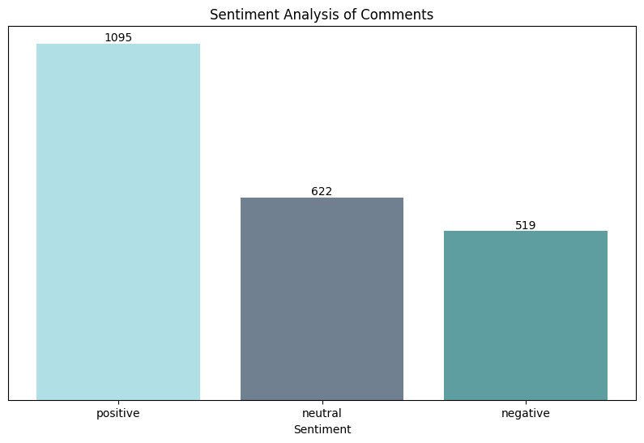

```python
import pandas as pd
from textblob import TextBlob
import matplotlib.pyplot as plt
import re

# Sample combined_df data
# combined_df = pd.DataFrame({'comment': ['I love Schwab!', 'TD Ameritrade is terrible.', 'Investing with Schwab has been great.', 'I hate using TD.', 'Schwab is just okay.']})

# Function to clean text
def clean_text(text):
    # Convert to lowercase
    text = text.lower()
    # Remove URLs
    text = re.sub(r'http\S+|www\S+|https\S+', '', text, flags=re.MULTILINE)
    # Remove special characters, emojis, and punctuations
    text = re.sub(r'[^a-zA-Z\s]', '', text)
    # Remove newlines and extra spaces
    text = re.sub(r'\s+', ' ', text).strip()
    return text

# Clean the comments
combined_df['cleaned_comment'] = combined_df['comment'].apply(clean_text)

# Function to get sentiment
def get_sentiment(text):
    analysis = TextBlob(text)
    if analysis.sentiment.polarity > 0:
        return 'positive'
    elif analysis.sentiment.polarity == 0:
        return 'neutral'
    else:
        return 'negative'

# Apply sentiment analysis to the cleaned comments
combined_df['sentiment'] = combined_df['cleaned_comment'].apply(get_sentiment)

# Count the number of comments in each sentiment category
sentiment_counts = combined_df['sentiment'].value_counts()

# Plot the sentiment distribution
plt.figure(figsize=(10, 6))
bars = plt.bar(sentiment_counts.index, sentiment_counts.values, color=['powderblue', 'slategrey', 'cadetblue'])

# Add number labels on top of each bar
for bar in bars:
    height = bar.get_height()
    plt.text(bar.get_x() + bar.get_width() / 2.0, height, f'{height}', ha='center', va='bottom')

# Customize the plot
plt.xlabel('Sentiment')
plt.ylabel('Number of Comments')
plt.title('Sentiment Analysis of Comments')
plt.gca().axes.get_yaxis().set_visible(False)  # Remove y-axis

# Show the plot
plt.show()
```

### Sentiment Analysis on the Comments of the Combined Data Using Vader

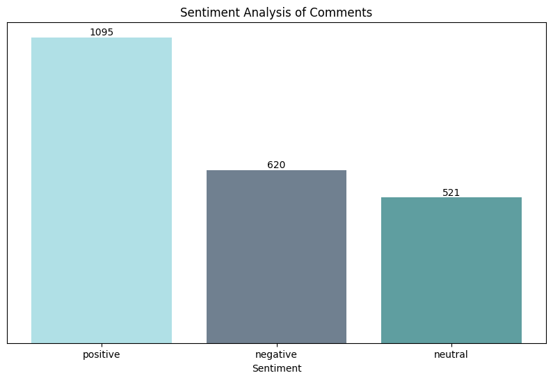

```python
import pandas as pd
import re
from nltk.sentiment.vader import SentimentIntensityAnalyzer
import matplotlib.pyplot as plt

# Ensure you have nltk downloaded and VADER installed
import nltk
nltk.download('vader_lexicon')

# Sample combined_df data
# combined_df = pd.DataFrame({'comment': ['I love Schwab!', 'TD Ameritrade is terrible.', 'Investing with Schwab has been great.', 'I hate using TD.', 'Schwab is just okay.']})

# Function to clean text
def clean_text(text):
    # Convert to lowercase
    text = text.lower()
    # Remove URLs
    text = re.sub(r'http\S+|www\S+|https\S+', '', text, flags=re.MULTILINE)
    # Remove special characters, emojis, and punctuations
    text = re.sub(r'[^a-zA-Z\s]', '', text)
    # Remove newlines and extra spaces
    text = re.sub(r'\s+', ' ', text).strip()
    return text

# Clean the comments
combined_df['cleaned_comment'] = combined_df['comment'].apply(clean_text)

# Initialize VADER sentiment analyzer
sid = SentimentIntensityAnalyzer()

# Function to get sentiment using VADER
def get_sentiment_vader(text):
    scores = sid.polarity_scores(text)
    if scores['compound'] > 0.05:
        return 'positive'
    elif scores['compound'] < -0.05:
        return 'negative'
    else:
        return 'neutral'

# Apply sentiment analysis to the cleaned comments
combined_df['sentiment'] = combined_df['cleaned_comment'].apply(get_sentiment_vader)

# Count the number of comments in each sentiment category
sentiment_counts = combined_df['sentiment'].value_counts()

# Plot the sentiment distribution
plt.figure(figsize=(10, 6))
bars = plt.bar(sentiment_counts.index, sentiment_counts.values, color=['powderblue', 'slategrey', 'cadetblue'])

# Add number labels on top of each bar
for bar in bars:
    height = bar.get_height()
    plt.text(bar.get_x() + bar.get_width() / 2.0, height, f'{height}', ha='center', va='bottom')

# Customize the plot
plt.xlabel('Sentiment')
plt.ylabel('Number of Comments')
plt.title('Sentiment Analysis of Comments')
plt.gca().axes.get_yaxis().set_visible(False)  # Remove y-axis

# Show the plot
plt.show()
```

We get similar results because they're both lexicon-based sentiment analysis models with predefined rules for words/lexicons.

### Topic Modeling on the Comments of the Combined Data

```python
!pip install gensim
!pip install pyLDAvis
!pip install nltk
```

```python
import pandas as pd
import re
import gensim
import gensim.corpora as corpora
from gensim.models import LdaModel
from nltk.corpus import stopwords
from nltk.tokenize import word_tokenize
import pyLDAvis
import pyLDAvis.gensim_models
import matplotlib.pyplot as plt
from nltk.stem import WordNetLemmatizer
from nltk.corpus import wordnet
from nltk import pos_tag

# Ensure you have nltk data downloaded
import nltk
nltk.download('stopwords')
nltk.download('punkt')
nltk.download('wordnet')
nltk.download('averaged_perceptron_tagger')

# Sample combined_df data
# combined_df = pd.DataFrame({'comment': ['Example comment about Schwab and TD Ameritrade.', 'Another comment with emojis 😊 and special characters!']})

# Function to clean text
def clean_text(text):
    # Convert to lowercase
    text = text.lower()
    # Remove URLs
    text = re.sub(r'http\S+|www\S+|https\S+', '', text, flags=re.MULTILINE)
    # Remove special characters, emojis, and punctuations
    text = re.sub(r'[^a-zA-Z\s]', '', text)
    # Remove newlines and extra spaces
    text = re.sub(r'\s+', ' ', text).strip()
    return text

# Clean the comments
combined_df['cleaned_comment'] = combined_df['comment'].apply(clean_text)

# Prepare stopwords and lemmatizer
stop_words = set(stopwords.words('english'))
additional_stopwords = {'schwab', 'td', 'td ameritrade', 'investing', 'tda', 'charles schwab', 'im', 'dont', 'will', 'ive','use', 'now', 'think', 'used'}
stop_words = stop_words.union(additional_stopwords)
lemmatizer = WordNetLemmatizer()

# Function to get POS tag for lemmatization
def get_wordnet_pos(word):
    tag = pos_tag([word])[0][1][0].upper()
    tag_dict = {"J": wordnet.ADJ,
                "N": wordnet.NOUN,
                "V": wordnet.VERB,
                "R": wordnet.ADV}
    return tag_dict.get(tag, wordnet.NOUN)

# Function to preprocess text for LDA
def preprocess_text(text):
    tokens = word_tokenize(text)
    tokens = [lemmatizer.lemmatize(word, get_wordnet_pos(word)) for word in tokens if word not in stop_words and len(word) > 2]
    return tokens

# Preprocess the comments
combined_df['tokens'] = combined_df['cleaned_comment'].apply(preprocess_text)

# Create dictionary and corpus
id2word = corpora.Dictionary(combined_df['tokens'])
corpus = [id2word.doc2bow(text) for text in combined_df['tokens']]

# Build LDA model
lda_model = LdaModel(corpus=corpus,
                     id2word=id2word,
                     num_topics=3,
                     random_state=42,
                     update_every=1,
                     chunksize=100,
                     passes=10,
                     alpha='auto',
                     per_word_topics=True)

# Print the topics
topics = lda_model.print_topics()
for topic in topics:
    print(topic)

# Visualize the topics
pyLDAvis.enable_notebook()
vis = pyLDAvis.gensim_models.prepare(lda_model, corpus, id2word)
pyLDAvis.display(vis)
```

```
(0, '0.041*"app" + 0.020*"well" + 0.019*"like" + 0.017*"get" + 0.013*"tos" + 0.011*"trading" + 0.010*"want" + 0.010*"broker" + 0.010*"really" + 0.010*"would"')
(1, '0.052*"account" + 0.015*"day" + 0.013*"transfer" + 0.013*"year" + 0.011*"money" + 0.011*"say" + 0.011*"transition" + 0.011*"trade" + 0.010*"get" + 0.010*"open"')
(2, '0.026*"fidelity" + 0.020*"move" + 0.017*"see" + 0.014*"fee" + 0.013*"great" + 0.013*"cant" + 0.013*"robinhood" + 0.010*"havent" + 0.010*"position" + 0.008*"pay"')
```

[interactive chart not shown]

### Combined Posts Data

```python
# List of submission URLs
submission_urls = [
    #r/Schwab Posts
      #Not happy with transition from TD to Schwab
      'https://www.reddit.com/r/Schwab/comments/13vumbz/not_happy_with_transition_from_td_to_schwab/',
      #I miss TD Ameritrade!!
      'https://www.reddit.com/r/Schwab/comments/1cg38sl/i_miss_td_ameritrade/',
      #TD Ameritrade customers want app back according to wall street journal..
      'https://www.reddit.com/r/Schwab/comments/16rzraa/td_ameritrade_customers_want_app_back_according/',
      #Anyone else from TD hate the Schwab app?
      'https://www.reddit.com/r/Schwab/comments/1cpxijs/anyone_else_from_td_hate_the_schwab_app/',
      #Td ameritrade
      'https://www.reddit.com/r/Schwab/comments/144dkcl/td_ameritrade/',
    #r/TD Ameritrade Posts
      #Charles Schwab sucks!
      'https://www.reddit.com/r/tdameritrade/comments/18llbx4/charles_schwab_sucks/',
      #Schwab is a fucking joke
      'https://www.reddit.com/r/tdameritrade/comments/1axjnpv/schwab_is_a_fucking_joke/',
      #Schwab sucks so hard
      'https://www.reddit.com/r/tdameritrade/comments/1cr42jt/schwab_sucks_so_hard/',
      #Charles Schwab
      'https://www.reddit.com/r/tdameritrade/comments/18745xa/charles_schwab/',
      #Is the migration to Schwab that bad?
      'https://www.reddit.com/r/tdameritrade/comments/1axx4uc/is_the_migration_to_schwab_that_bad/',
    #r/Investing posts
      #Charles Schwab App is horrible
      'https://www.reddit.com/r/investing/comments/1cev38m/charles_schwab_app_is_horrible/',
      #The Schwab app is garbage and I miss TDA
      'https://www.reddit.com/r/investing/comments/13wj08y/the_schwab_app_is_garbage_and_i_miss_tda/',
      #People who were transitioned from TD Ameritrade to Schwab, do any of you actually like Schwab?
      'https://www.reddit.com/r/investing/comments/142rvp5/people_who_were_transitioned_from_td_ameritrade/',
      #Schwab ? Making the change 😬 ?
      'https://www.reddit.com/r/investing/comments/1b1lb90/schwab_making_the_change/',
      #I can't continue with the charles schwab app.
      'https://www.reddit.com/r/investing/comments/1bp383z/i_cant_continue_with_the_charles_schwab_app/'

]

# Prepare a list to hold all post details
posts_info = []

# Loop through each submission URL
for submission_url in submission_urls:
    # Extract the submission ID from the URL
    submission_id = submission_url.split('/')[-3]

    # Fetch the submission
    submission = reddit.submission(id=submission_id)

    # Collect post information
    post_info = {
        'URL': submission_url,
        'Author': submission.author.name if submission.author else 'N/A',
        'Date': datetime.fromtimestamp(submission.created_utc).strftime('%Y-%m-%d %H:%M:%S'),
        'Title': submission.title,
        'Post Text': submission.selftext,
        'Subreddit': submission.subreddit.display_name,
        'Upvotes': submission.ups,
        'Downvotes': submission.downs,
        'Upvote Ratio': submission.upvote_ratio,
        'Total Awards': submission.total_awards_received,
        'Number of Comments': submission.num_comments
    }

    posts_info.append(post_info)

# Create a DataFrame from the list of post details
posts_df = pd.DataFrame(posts_info)
```

```python
# Display the DataFrame
posts_df
```

|  | URL | Author | Date | Title | Post Text | Subreddit | Upvotes | Downvotes | Upvote Ratio | Total Awards | Number of Comments |
| --- | --- | --- | --- | --- | --- | --- | --- | --- | --- | --- | --- |
| 0 | https://www.reddit.com/r/Schwab/comments/13vum... | TheRealBrewder | 2023-05-30 16:17:41 | Not happy with transition from TD to Schwab | The old TD Ameritrade website (and mobile app)... | Schwab | 193 | 0 | 0.93 | 0 | 337 |
| 1 | https://www.reddit.com/r/Schwab/comments/1cg38... | DSCN__034 | 2024-04-29 16:20:10 | I miss TD Ameritrade!! | \n\nOkay, I'm just going to vent for a minute... | Schwab | 25 | 0 | 0.59 | 0 | 70 |
| 2 | https://www.reddit.com/r/Schwab/comments/16rzr... | KCGuy59 | 2023-09-25 18:24:26 | TD Ameritrade customers want app back accordin... | Funny how several weeks ago some of you old sc... | Schwab | 276 | 0 | 0.90 | 0 | 200 |
| 3 | https://www.reddit.com/r/Schwab/comments/1cpxi... | BlueHorseShoe_2021 | 2024-05-12 02:24:41 | Anyone else from TD hate the Schwab app? | Getting transferred over finally and the app i... | Schwab | 0 | 0 | 0.38 | 0 | 39 |
| 4 | https://www.reddit.com/r/Schwab/comments/144dk... | administrator28 | 2023-06-08 16:16:58 | Td ameritrade | This app is complete garbage compared to td am... | Schwab | 0 | 0 | 0.46 | 0 | 52 |
| 5 | https://www.reddit.com/r/tdameritrade/comments... | HandIcy161 | 2023-12-18 22:19:53 | Charles Schwab sucks! | I am moving my six figure account to Fidelity.... | tdameritrade | 52 | 0 | 0.84 | 0 | 49 |
| 6 | https://www.reddit.com/r/tdameritrade/comments... | DoctorChang420 | 2024-02-22 22:23:11 | Schwab is a fucking joke | Deposited my check 2/16 and was told my funds ... | tdameritrade | 188 | 0 | 0.77 | 0 | 249 |
| 7 | https://www.reddit.com/r/tdameritrade/comments... | bendraw | 2024-05-13 16:49:39 | Schwab sucks so hard | It’s just the worst. | tdameritrade | 53 | 0 | 0.79 | 0 | 138 |
| 8 | https://www.reddit.com/r/tdameritrade/comments... | YesterdaySad1198 | 2023-11-30 00:01:58 | Charles Schwab | Is anyone actually happy with the transfer to ... | tdameritrade | 51 | 0 | 0.87 | 0 | 103 |
| 9 | https://www.reddit.com/r/tdameritrade/comments... | sbd0223 | 2024-02-23 10:16:11 | Is the migration to Schwab that bad? | I see tons of new posts either complaining or ... | tdameritrade | 58 | 0 | 0.90 | 0 | 157 |
| 10 | https://www.reddit.com/r/investing/comments/1c... | Low_Impression_9204 | 2024-04-28 01:55:31 | Charles Schwab App is horrible | Almost a year after acquiring TD , I still don... | investing | 309 | 0 | 0.79 | 0 | 159 |
| 11 | https://www.reddit.com/r/investing/comments/13... | Nbtanbta | 2023-05-31 11:01:55 | The Schwab app is garbage and I miss TDA | Switched over yesterday and am having a hard t... | investing | 806 | 0 | 0.90 | 0 | 403 |
| 12 | https://www.reddit.com/r/investing/comments/14... | xkulp8 | 2023-06-06 20:13:15 | People who were transitioned from TD Ameritrad... | **Edit: Made a call to Schwab and now have Str... | investing | 112 | 0 | 0.82 | 0 | 174 |
| 13 | https://www.reddit.com/r/investing/comments/1b... | Successful_Flow7171 | 2024-02-27 19:58:12 | Schwab ? Making the change 😬 ? | Have been a T.D. Ameritrade customer for a few... | investing | 39 | 0 | 0.84 | 0 | 83 |
| 14 | https://www.reddit.com/r/investing/comments/1b... | Jeffsdrunkdog | 2024-03-27 14:28:07 | I can't continue with the charles schwab app. | The user interface of the schwab app compared ... | investing | 0 | 0 | 0.37 | 0 | 28 |

Download posts data into excel - saving to csv creates data issues

```python
# Save the DataFrame to an Excel file
posts_df.to_excel('posts_data.xlsx', index=False, engine='openpyxl')
```

### Average Upvote Ratio by Subreddit

This is for the posts we analyzed

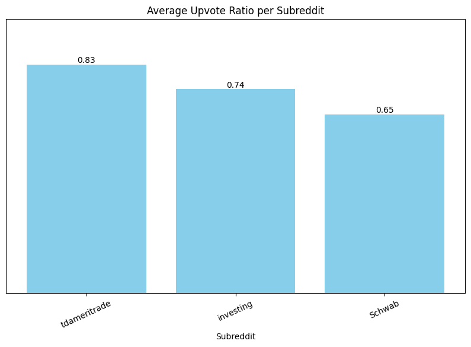

```python
# Calculate the average upvote ratio per subreddit
average_upvote_ratio = posts_df.groupby('Subreddit')['Upvote Ratio'].mean().reset_index()

# Sort by Upvote Ratio
average_upvote_ratio = average_upvote_ratio.sort_values(by='Upvote Ratio', ascending=False)

# Plot the average upvote ratio per subreddit
plt.figure(figsize=(10, 6))
bars = plt.bar(average_upvote_ratio['Subreddit'], average_upvote_ratio['Upvote Ratio'], color='skyblue')

# Add data labels on top of each bar
for bar in bars:
    height = bar.get_height()
    plt.text(bar.get_x() + bar.get_width() / 2.0, height, f'{height:.2f}', ha='center', va='bottom')

plt.xlabel('Subreddit')
plt.ylabel('Average Upvote Ratio')
plt.title('Average Upvote Ratio per Subreddit')
plt.xticks(rotation=25)
plt.ylim(0, 1)  # Upvote ratio is between 0 and 1

# Remove y-axis
plt.gca().axes.get_yaxis().set_visible(False)
#show the plot
plt.show()
```

As we can see, most of the people agree with the posts posted on these subreddits but the users on TD Ameritrade tend to agree more with the posts as opposed to the users on schwab posts which makes sense because there would more schwab fans on the schwab subbredit than TD or Investing subreddit logically speaking.

### Sentiment Analysis on the Combined Posts Title Using VADER

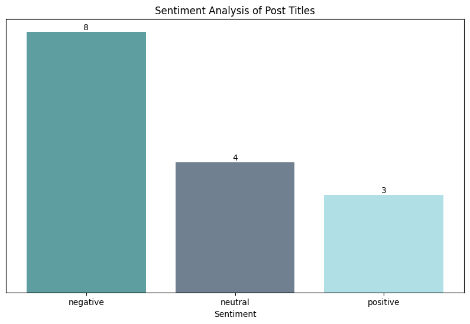

```python
import pandas as pd
import re
from nltk.sentiment.vader import SentimentIntensityAnalyzer
import matplotlib.pyplot as plt

# Ensure you have nltk downloaded and VADER installed
import nltk
nltk.download('vader_lexicon')

# Function to clean text
def clean_text(text):
    # Convert to lowercase
    text = text.lower()
    # Remove URLs
    text = re.sub(r'http\S+|www\S+|https\S+', '', text, flags=re.MULTILINE)
    # Remove special characters, emojis, and punctuations
    text = re.sub(r'[^a-zA-Z\s]', '', text)
    # Remove newlines and extra spaces
    text = re.sub(r'\s+', ' ', text).strip()
    return text

# Initialize VADER sentiment analyzer
sid = SentimentIntensityAnalyzer()

# Function to get sentiment using VADER
def get_sentiment_vader(text):
    scores = sid.polarity_scores(text)
    if scores['compound'] > 0.05:
        return 'positive'
    elif scores['compound'] < -0.05:
        return 'negative'
    else:
        return 'neutral'

# Assuming posts_df is already defined with the required data
# Clean the titles
posts_df['cleaned_title'] = posts_df['Title'].apply(clean_text)

# Apply sentiment analysis to the cleaned titles
posts_df['sentiment'] = posts_df['cleaned_title'].apply(get_sentiment_vader)

# Count the number of titles in each sentiment category
sentiment_counts = posts_df['sentiment'].value_counts()

# Plot the sentiment distribution
plt.figure(figsize=(10, 6))
bars = plt.bar(sentiment_counts.index, sentiment_counts.values, color=['cadetblue', 'slategrey', 'powderblue'])

# Add number labels on top of each bar
for bar in bars:
    height = bar.get_height()
    plt.text(bar.get_x() + bar.get_width() / 2.0, height, f'{height}', ha='center', va='bottom')

# Customize the plot
plt.xlabel('Sentiment')
plt.ylabel('Number of Titles')
plt.title('Sentiment Analysis of Post Titles')
plt.gca().axes.get_yaxis().set_visible(False)  # Remove y-axis
# Show the plot
plt.show()
```

### Most Influential Users Across the 3 Subreddits

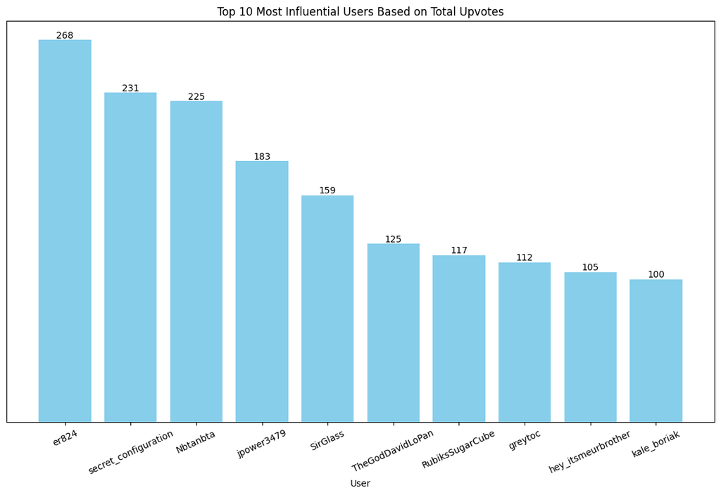

```python
import pandas as pd
import matplotlib.pyplot as plt

# Sample combined_df data
# combined_df = pd.DataFrame({
#     'author': ['user1', 'user2', 'user3', 'user1', 'user2', 'user4', 'user3', 'user4', 'user5', 'user6', None],
#     'upvotes': [100, 150, 200, 300, 250, 50, 75, 125, 175, 100, 50]
# })

# Filter out rows where the author is NA or 'N/A'
filtered_df = combined_df.dropna(subset=['author'])
filtered_df = filtered_df[filtered_df['author'] != 'N/A']

# Group by author and sum the upvotes
author_upvotes = filtered_df.groupby('author')['upvotes'].sum().reset_index()

# Sort by upvotes in descending order and get the top 10 authors
top_10_authors = author_upvotes.sort_values(by='upvotes', ascending=False).head(10)

# Plot the top 10 authors
plt.figure(figsize=(14, 8))
bars = plt.bar(top_10_authors['author'], top_10_authors['upvotes'], color='skyblue')

# Add number labels on top of each bar
for bar in bars:
    height = bar.get_height()
    plt.text(bar.get_x() + bar.get_width() / 2.0, height, f'{height}', ha='center', va='bottom')

# Customize the plot
plt.xlabel('User')
plt.ylabel('Total Upvotes')
plt.title('Top 10 Most Influential Users Based on Total Upvotes')
plt.xticks(rotation=25)
plt.gca().axes.get_yaxis().set_visible(False)  # Remove y-axis
# Show the plot
plt.show()
```

## Comparison: E-Trade Acquisition by Morgan Stanley

### r/Etrade Data Scrapping

```python
# Initialize PRAW with your credentials
reddit = praw.Reddit(client_id='XSgoIvpkuSEVUUlRli7TWA',
                     client_secret='BGgAch-x9zpipnl4FrdPkRS9xiMs1g',
                     user_agent='Falmata238')

# List of submission URLs
submission_urls = [
    #Cold call from Morgan Stanley rep
    'https://www.reddit.com/r/etrade/comments/1axk5fa/cold_call_from_morgan_stanley_rep/',
    #E trade has went downhill since Morgan Stanley !
    'https://www.reddit.com/r/etrade/comments/1btwjam/e_trade_has_went_downhill_since_morgan_stanley/',
    #Morgan Stanley Broke the Bank
    'https://www.reddit.com/r/etrade/comments/1cefr8k/morgan_stanley_broke_the_bank/',
    #Morgan Stanley messed up Etrade
    'https://www.reddit.com/r/etrade/comments/1b00229/morgan_stanley_messed_up_etrade/',
    #Is it just me or has ETrade’s service went to shit once MS took them over?
    'https://www.reddit.com/r/etrade/comments/1avxzij/is_it_just_me_or_has_etrades_service_went_to_shit/'
]

# Helper function to generate hierarchical comment IDs
def generate_comment_hierarchy(submission):
    comment_id_map = {submission.id: '1'}
    comment_hierarchy = []

    def add_comments(comments, parent_id):
        current_level = len(comment_hierarchy)
        for i, comment in enumerate(comments, 1):
            if isinstance(comment, praw.models.MoreComments):
                continue
            comment_id = f"{comment_id_map[parent_id]}_{i}"
            comment_id_map[comment.id] = comment_id
            comment_hierarchy.append({
                'url': submission.url,
                'author': comment.author.name if comment.author else 'N/A',
                'date': datetime.fromtimestamp(comment.created_utc).strftime('%Y-%m-%d %H:%M:%S'),
                'score': comment.score,
                'upvotes': comment.ups,
                'downvotes': comment.downs,
                'golds': comment.gilded,
                'comment': comment.body,
                'comment_id': comment_id,
                'post_title': submission.title,
                'post_text': submission.selftext,
                'subreddit': submission.subreddit.display_name
            })
            add_comments(comment.replies, comment.id)

    add_comments(submission.comments, submission.id)
    return comment_hierarchy

# Prepare a list to hold all comment details from all posts
all_comments = []

# Loop through each submission URL
for submission_url in submission_urls:
    # Extract the submission ID from the URL
    submission_id = submission_url.split('/')[-3]

    # Fetch the submission
    submission = reddit.submission(id=submission_id)

    # Fetch the submission details
    submission.comments.replace_more(limit=None)  # Handle cases with more than 1 level of comments

    # Generate hierarchical comments
    all_comments.extend(generate_comment_hierarchy(submission))

# Create a DataFrame from the list of all comments
Etradedf = pd.DataFrame(all_comments)
```

```python
# Display the DataFrame
Etradedf
```

|  | url | author | date | score | upvotes | downvotes | golds | comment | comment_id | post_title | post_text | subreddit |
| --- | --- | --- | --- | --- | --- | --- | --- | --- | --- | --- | --- | --- |
| 0 | https://www.reddit.com/r/etrade/comments/1axk5... | TheDaddyShip | 2024-02-23 00:12:39 | 13 | 13 | 0 | 0 | I called in to their active trader services no... | 1_1 | Cold call from Morgan Stanley rep | I've been a long time Etrade customer. When I... | etrade |
| 1 | https://www.reddit.com/r/etrade/comments/1axk5... | Comfortable-Scar4643 | 2024-02-24 14:12:10 | 1 | 1 | 0 | 0 | The Morgan Stanley side won’t allow options tr... | 1_1_1 | Cold call from Morgan Stanley rep | I've been a long time Etrade customer. When I... | etrade |
| 2 | https://www.reddit.com/r/etrade/comments/1axk5... | botpa-94027 | 2024-02-24 17:20:02 | 3 | 3 | 0 | 0 | Really? I've done that through my MS FA. Requi... | 1_1_1_1 | Cold call from Morgan Stanley rep | I've been a long time Etrade customer. When I... | etrade |
| 3 | https://www.reddit.com/r/etrade/comments/1axk5... | Comfortable-Scar4643 | 2024-02-24 18:46:03 | 5 | 5 | 0 | 0 | I stand corrected. | 1_1_1_1_1 | Cold call from Morgan Stanley rep | I've been a long time Etrade customer. When I... | etrade |
| 4 | https://www.reddit.com/r/etrade/comments/1axk5... | bigswingingtexasdick | 2024-02-25 01:04:25 | 2 | 2 | 0 | 0 | Makes sense that y'all have all had different ... | 1_1_1_1_1_1 | Cold call from Morgan Stanley rep | I've been a long time Etrade customer. When I... | etrade |
| ... | ... | ... | ... | ... | ... | ... | ... | ... | ... | ... | ... | ... |
| 368 | https://www.reddit.com/r/etrade/comments/1avxz... | Therealmohb | 2024-02-23 15:12:47 | 1 | 1 | 0 | 0 | No issues since around 2003. Only contacted CS... | 1_34 | Is it just me or has ETrade’s service went to ... | I have had a Rollover IRA account with ETrade ... | etrade |
| 369 | https://www.reddit.com/r/etrade/comments/1avxz... | MCKlassik | 2024-02-23 21:51:09 | 1 | 1 | 0 | 0 | I recently moved to Fidelity and I’m not looki... | 1_35 | Is it just me or has ETrade’s service went to ... | I have had a Rollover IRA account with ETrade ... | etrade |
| 370 | https://www.reddit.com/r/etrade/comments/1avxz... | Terrible_Champion298 | 2024-02-24 05:42:58 | 1 | 1 | 0 | 0 | This is the most disturbing E*Trade story I’ve... | 1_36 | Is it just me or has ETrade’s service went to ... | I have had a Rollover IRA account with ETrade ... | etrade |
| 371 | https://www.reddit.com/r/etrade/comments/1avxz... | N/A | 2024-02-25 13:31:47 | 1 | 1 | 0 | 0 | Opened up my E*trade account in 2003 in high s... | 1_37 | Is it just me or has ETrade’s service went to ... | I have had a Rollover IRA account with ETrade ... | etrade |
| 372 | https://www.reddit.com/r/etrade/comments/1avxz... | According-Record-972 | 2024-02-28 15:52:09 | 1 | 1 | 0 | 0 | Their website seems to be not functioning this... | 1_38 | Is it just me or has ETrade’s service went to ... | I have had a Rollover IRA account with ETrade ... | etrade |

373 rows × 12 columns

### E-Trade Word Cloud on Comments

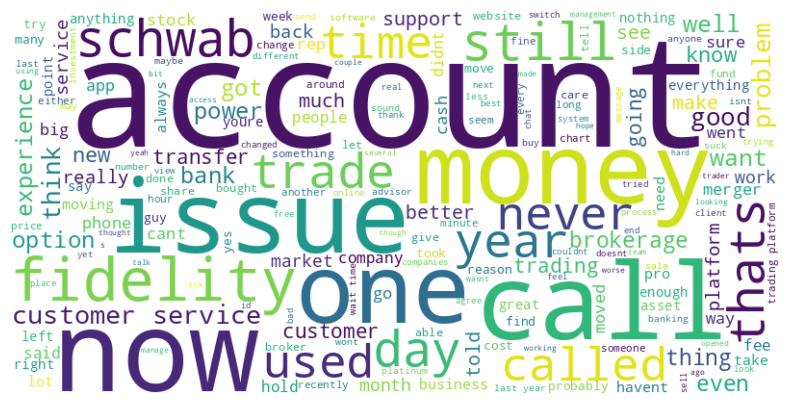

```python
from wordcloud import WordCloud, STOPWORDS
import matplotlib.pyplot as plt
import re
import pandas as pd

# Assuming Etradedf is your DataFrame with comments about E*TRADE
# Sample data for Etradedf
# Etradedf = pd.DataFrame({'comment': ['Example comment about E*TRADE and Morgan Stanley.', 'Another comment with emojis 😊 and special characters!']})

# Function to clean text
def clean_text(text):
    # Convert to lowercase
    text = text.lower()
    # Remove URLs
    text = re.sub(r'http\S+|www\S+|https\S+', '', text, flags=re.MULTILINE)
    # Remove special characters, emojis, and punctuations
    text = re.sub(r'[^a-zA-Z\s]', '', text)
    # Remove newlines and extra spaces
    text = re.sub(r'\s+', ' ', text).strip()
    return text

# List of additional stopwords to remove
additional_stopwords = set([
    'etrade', 'e*trade', 'morgan', 'stanley', 'im', 'dont', 'will', 'ive', 'use', 'morgan stanley', 'MS', 'e-trade'
])

# Clean the comments and remove stopwords
Etradedf['cleaned_comment'] = Etradedf['comment'].apply(clean_text)

# Combine all comments into a single string
all_comments = ' '.join(Etradedf['cleaned_comment'].tolist())

# Add additional stopwords to the default stopwords set
stopwords = STOPWORDS.union(additional_stopwords)

# Generate the word cloud
wordcloud = WordCloud(
    stopwords=stopwords,
    background_color='white',
    width=800,
    height=400
).generate(all_comments)

# Plot the word cloud
plt.figure(figsize=(10, 5))
plt.imshow(wordcloud, interpolation='bilinear')
plt.axis('off')
# plt.title('Word Cloud for E*TRADE Comments')
plt.show()
```

### Word Frequency in Comments

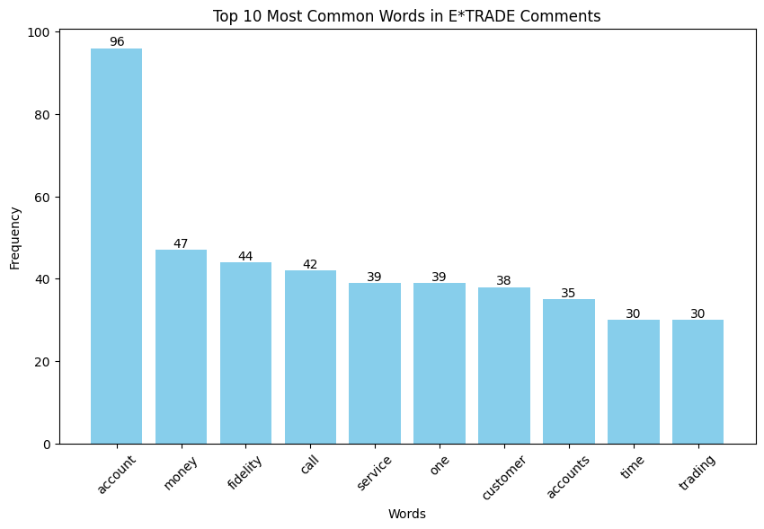

```python
import pandas as pd
from collections import Counter
import re
import matplotlib.pyplot as plt
from wordcloud import STOPWORDS

# Assuming Etradedf is your DataFrame with comments about E*TRADE
# Sample data for Etradedf
# Etradedf = pd.DataFrame({'comment': ['Example comment about E*TRADE and Morgan Stanley.', 'Another comment with emojis 😊 and special characters!']})

# Function to clean text
def clean_text(text):
    # Convert to lowercase
    text = text.lower()
    # Remove URLs
    text = re.sub(r'http\S+|www\S+|https\S+', '', text, flags=re.MULTILINE)
    # Remove special characters, emojis, and punctuations
    text = re.sub(r'[^a-zA-Z\s]', '', text)
    # Remove newlines and extra spaces
    text = re.sub(r'\s+', ' ', text).strip()
    return text

# List of additional stopwords to remove
additional_stopwords = set([
    'etrade', 'e*trade', 'morgan', 'stanley', 'im', 'dont', 'will', 'ive', 'use', 'morgan stanley', 'MS', 'e-trade', 'ms', 'now', 'still', 'thats'
])

# Clean the comments and remove stopwords
Etradedf['cleaned_comment'] = Etradedf['comment'].apply(clean_text)

# Combine all comments into a single string
all_comments = ' '.join(Etradedf['cleaned_comment'].tolist())

# Split the combined string into words
words = all_comments.split()

# Remove stopwords from the words list
filtered_words = [word for word in words if word not in additional_stopwords and word not in STOPWORDS]

# Get the frequency of each word
word_freq = Counter(filtered_words)

# Convert the frequency data to a DataFrame for better visualization
freq_df = pd.DataFrame(word_freq.items(), columns=['Word', 'Frequency']).sort_values(by='Frequency', ascending=False)

# Get the top 10 most common words
top_10_words = freq_df.head(10)

# Plot the top 10 most common words
plt.figure(figsize=(10, 6))
bars = plt.bar(top_10_words['Word'], top_10_words['Frequency'], color='skyblue')

# Add data labels on top of each bar
for bar in bars:
    height = bar.get_height()
    plt.text(bar.get_x() + bar.get_width() / 2.0, height, f'{height}', ha='center', va='bottom')

# Customize the plot
plt.xlabel('Words')
plt.ylabel('Frequency')
plt.title('Top 10 Most Common Words in E*TRADE Comments')
plt.xticks(rotation=45)
#show the plot
plt.show()
```

### Sentiment Analysis on Comment

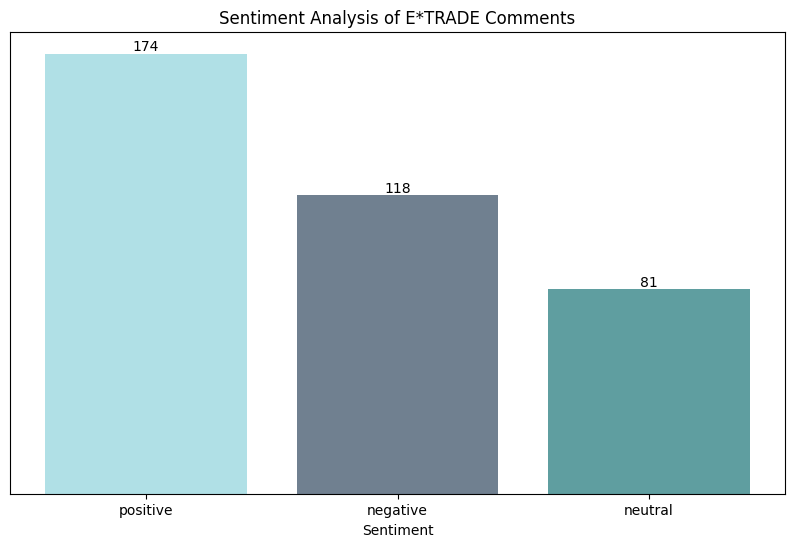

```python
import pandas as pd
import re
from nltk.sentiment.vader import SentimentIntensityAnalyzer
import matplotlib.pyplot as plt

# Ensure you have nltk downloaded and VADER installed
import nltk
nltk.download('vader_lexicon')

# Sample Etradedf data
# Etradedf = pd.DataFrame({'comment': ['I love E*TRADE!', 'Morgan Stanley is terrible.', 'Investing with E*TRADE has been great.', 'I hate using Morgan Stanley.', 'E*TRADE is just okay.']})

# Function to clean text
def clean_text(text):
    # Convert to lowercase
    text = text.lower()
    # Remove URLs
    text = re.sub(r'http\S+|www\S+|https\S+', '', text, flags=re.MULTILINE)
    # Remove special characters, emojis, and punctuations
    text = re.sub(r'[^a-zA-Z\s]', '', text)
    # Remove newlines and extra spaces
    text = re.sub(r'\s+', ' ', text).strip()
    return text

# Initialize VADER sentiment analyzer
sid = SentimentIntensityAnalyzer()

# Function to get sentiment using VADER
def get_sentiment_vader(text):
    scores = sid.polarity_scores(text)
    if scores['compound'] > 0.05:
        return 'positive'
    elif scores['compound'] < -0.05:
        return 'negative'
    else:
        return 'neutral'

# Assuming Etradedf is already defined with the required data
# Clean the comments
Etradedf['cleaned_comment'] = Etradedf['comment'].apply(clean_text)

# Apply sentiment analysis to the cleaned comments
Etradedf['sentiment'] = Etradedf['cleaned_comment'].apply(get_sentiment_vader)

# Count the number of comments in each sentiment category
sentiment_counts = Etradedf['sentiment'].value_counts()

# Plot the sentiment distribution
plt.figure(figsize=(10, 6))
bars = plt.bar(sentiment_counts.index, sentiment_counts.values, color=['powderblue', 'slategrey', 'cadetblue'])

# Add number labels on top of each bar
for bar in bars:
    height = bar.get_height()
    plt.text(bar.get_x() + bar.get_width() / 2.0, height, f'{height}', ha='center', va='bottom')

# Customize the plot
plt.xlabel('Sentiment')
plt.ylabel('Number of Comments')
plt.title('Sentiment Analysis of E*TRADE Comments')
plt.gca().axes.get_yaxis().set_visible(False)  # Remove y-axis
# Show the plot
plt.show()
```

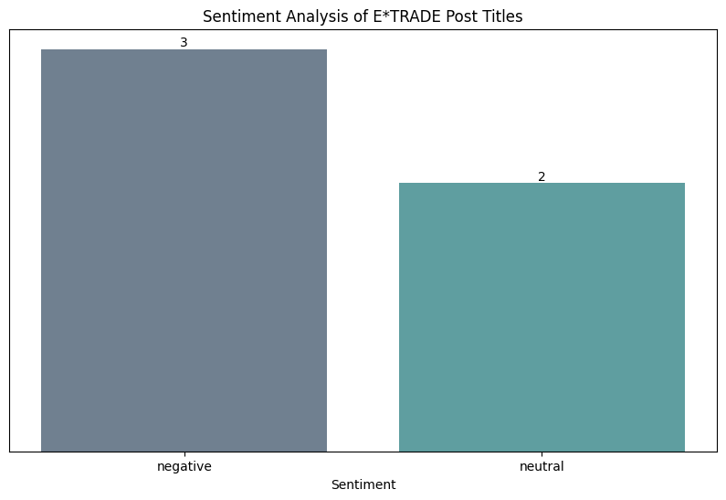

```python
import pandas as pd
import re
from nltk.sentiment.vader import SentimentIntensityAnalyzer
import matplotlib.pyplot as plt

# Ensure you have nltk downloaded and VADER installed
import nltk
nltk.download('vader_lexicon')

# Sample Etradedf data
# Etradedf = pd.DataFrame({
#     'post_title': [
#         'I love E*TRADE!', 'Morgan Stanley is terrible.', 'Investing with E*TRADE has been great.',
#         'I hate using Morgan Stanley.', 'E*TRADE is just okay.', 'I love E*TRADE!', 'Investing with E*TRADE has been great.'
#     ]
# })

# Function to clean text
def clean_text(text):
    # Convert to lowercase
    text = text.lower()
    # Remove URLs
    text = re.sub(r'http\S+|www\S+|https\S+', '', text, flags=re.MULTILINE)
    # Remove special characters, emojis, and punctuations
    text = re.sub(r'[^a-zA-Z\s]', '', text)
    # Remove newlines and extra spaces
    text = re.sub(r'\s+', ' ', text).strip()
    return text

# Initialize VADER sentiment analyzer
sid = SentimentIntensityAnalyzer()

# Function to get sentiment using VADER
def get_sentiment_vader(text):
    scores = sid.polarity_scores(text)
    if scores['compound'] > 0.05:
        return 'positive'
    elif scores['compound'] < -0.05:
        return 'negative'
    else:
        return 'neutral'

# Assuming Etradedf is already defined with the required data
# Extract unique titles
unique_titles = Etradedf['post_title'].unique()

# Clean the unique titles
cleaned_titles = [clean_text(title) for title in unique_titles]

# Apply sentiment analysis to the cleaned titles
sentiments = [get_sentiment_vader(title) for title in cleaned_titles]

# Create a DataFrame for the sentiments
sentiment_df = pd.DataFrame({
    'post_title': unique_titles,
    'sentiment': sentiments
})

# Count the number of titles in each sentiment category
sentiment_counts = sentiment_df['sentiment'].value_counts()

# Plot the sentiment distribution
plt.figure(figsize=(10, 6))
bars = plt.bar(sentiment_counts.index, sentiment_counts.values, color=['slategrey', 'cadetblue', 'powderblue'])

# Add number labels on top of each bar
for bar in bars:
    height = bar.get_height()
    plt.text(bar.get_x() + bar.get_width() / 2.0, height, f'{height}', ha='center', va='bottom')

# Customize the plot
plt.xlabel('Sentiment')
plt.ylabel('Number of Titles')
plt.title('Sentiment Analysis of E*TRADE Post Titles')
plt.gca().axes.get_yaxis().set_visible(False)  # Remove y-axis
# Show the plot
plt.show()
```

### Topic Modeling on the Comments

```python
!pip install gensim nltk pyLDAvis
```

```python
import pandas as pd
import re
from nltk.corpus import stopwords
from nltk.tokenize import word_tokenize
from gensim import corpora
from gensim.models import LdaModel
import matplotlib.pyplot as plt
import pyLDAvis
import pyLDAvis.gensim_models as gensimvis

# Ensure you have nltk stopwords and punkt downloaded
import nltk
nltk.download('stopwords')
nltk.download('punkt')

# Sample Etradedf data
# Etradedf = pd.DataFrame({
#     'comment': [
#         'I love E*TRADE!', 'Morgan Stanley is terrible.', 'Investing with E*TRADE has been great.',
#         'I hate using Morgan Stanley.', 'E*TRADE is just okay.', 'I love E*TRADE!', 'Investing with E*TRADE has been great.'
#     ]
# })

# Function to clean text
def clean_text(text):
    # Convert to lowercase
    text = text.lower()
    # Remove URLs
    text = re.sub(r'http\S+|www\S+|https\S+', '', text, flags=re.MULTILINE)
    # Remove special characters, emojis, and punctuations
    text = re.sub(r'[^a-zA-Z\s]', '', text)
    # Remove newlines and extra spaces
    text = re.sub(r'\s+', ' ', text).strip()
    return text

# List of additional stopwords to remove
additional_stopwords = set([
    'etrade', 'e*trade', 'morgan', 'stanley', 'im', 'dont', 'will', 'ive', 'use', 'morgan stanley', 'MS', 'e-trade', 'ms', 'now', 'still', 'thats'
])

# Combine default and additional stopwords
stop_words = set(stopwords.words('english')).union(additional_stopwords)

# Clean the comments
Etradedf['cleaned_comment'] = Etradedf['comment'].apply(clean_text)

# Tokenize the cleaned comments
Etradedf['tokenized_comment'] = Etradedf['cleaned_comment'].apply(word_tokenize)

# Remove stopwords from tokenized comments
Etradedf['tokenized_comment'] = Etradedf['tokenized_comment'].apply(
    lambda tokens: [word for word in tokens if word not in stop_words]
)

# Create a dictionary representation of the documents
dictionary = corpora.Dictionary(Etradedf['tokenized_comment'])

# Create a corpus: list of bags of words
corpus = [dictionary.doc2bow(text) for text in Etradedf['tokenized_comment']]

# Set the number of topics
num_topics = 3

# Train the LDA model
lda_model = LdaModel(corpus=corpus, id2word=dictionary, num_topics=num_topics, random_state=42, passes=10)

# Print the topics
topics = lda_model.print_topics(num_words=10)
for topic in topics:
    print(topic)

# Visualize the topics
vis_data = gensimvis.prepare(lda_model, corpus, dictionary)
pyLDAvis.display(vis_data)
```

```
(0, '0.007*"call" + 0.007*"customer" + 0.007*"service" + 0.007*"account" + 0.006*"like" + 0.006*"used" + 0.006*"get" + 0.005*"called" + 0.005*"fidelity" + 0.005*"trading"')
(1, '0.022*"account" + 0.010*"get" + 0.009*"fidelity" + 0.009*"money" + 0.008*"schwab" + 0.008*"accounts" + 0.007*"like" + 0.007*"never" + 0.006*"customer" + 0.006*"one"')
(2, '0.010*"like" + 0.009*"trade" + 0.007*"since" + 0.007*"time" + 0.007*"power" + 0.006*"account" + 0.006*"money" + 0.006*"call" + 0.005*"one" + 0.005*"get"')
```

[interactive chart not shown]

Export File to HTML

```python
%%shell
jupyter nbconvert --to html /content/BIA_Capstone_Project_Code_Group_7.ipynb
```